# Indian E-commece Market Research

## Indian E-commece Market Research

### Key Indian E-Commerce Players

#### Major Platforms & Business Models

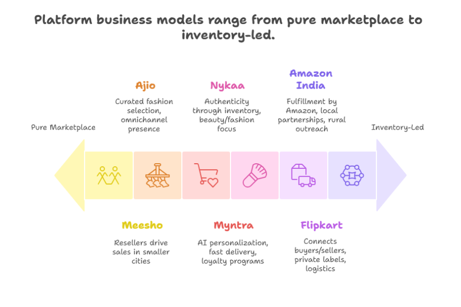

| Platform | Business Model(s) | Key Features & Expansion Strategies |
| --- | --- | --- |
| Flipkart | B2C, Marketplace | Marketplace connecting buyers/sellers, private labels, logistics (E-kart), subscription (Flipkart Plus), Big Billion Days sale |
| Amazon India | B2C, Marketplace | Marketplace, Fulfillment by Amazon (FBA), local partnerships, last-mile delivery, rural outreach, major festival sales |
| Meesho | Social Commerce, B2C | Social selling via resellers, focus on Tier 2+ cities, zero-investment business for individuals, logistics partnerships |
| Nykaa | Hybrid: Inventory + Marketplace, D2C | Inventory-led for authenticity, marketplace for scale, private labels for high margin, beauty/fashion focus |
| Myntra | Hybrid: Inventory + Marketplace, D2C | Marketplace + inventory, private labels, AI personalization, social commerce, loyalty programs, fast delivery (M-Express) |
| Ajio | Marketplace, D2C | Reliance-backed, fashion focus, private labels, curated selection, strong omnichannel presence |

#### Recent Trends

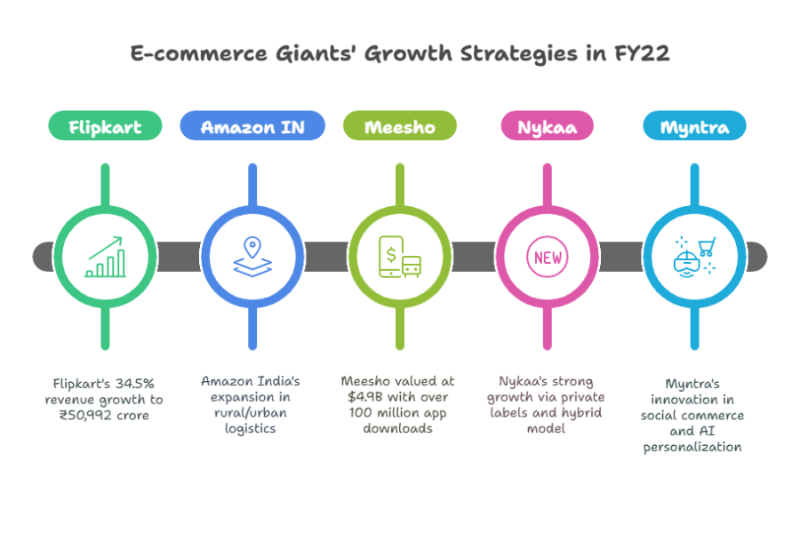

- `Flipkart:` *34.5%* revenue growth in *FY22 to ₹50,992 crore, 70%* repeat customers, heavy investment in logistics and private labels, aggressive festival sales.
- `Amazon India:` Expansion in rural/urban logistics, seller enablement programs, major investments in fulfillment centers, focus on Prime and festival sales.
- `Meesho:` Over *100 million* app downloads, rapid growth in Tier *2/3* cities, democratizing e-commerce for resellers, valued at *$4.9B*.
- `Nykaa:` Strong growth via private labels and hybrid model, expanded into fashion, focus on authenticity and premium experience.
- `Myntra:` Innovation in social commerce, AI-driven personalization, expansion into beauty, loyalty and influencer marketing.
- `Ajio:` Reliance’s digital push, fashion curation, omnichannel integration (not detailed in sources, but widely recognized in industry).

### Data-Driven Strategies in Indian E-Commerce

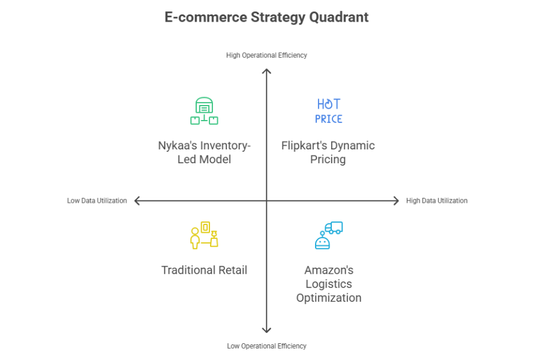

- `Personalized Marketing`
  - Companies leverage customer browsing, purchase, and demographic data to personalize recommendations, emails, and push notifications.
  - Myntra and Flipkart use AI/ML for tailored experiences, while Meesho uses social data for targeted reseller promotions.
- `Pricing Strategies`
  - Dynamic pricing is common: platforms adjust prices based on demand, competitor pricing, and inventory levels.
  - Flipkart and Amazon use real-time analytics to optimize prices during peak events (e.g., Big Billion Days, Great Indian Festival).
- `Logistics & Supply Chain Optimization`
  - Predictive analytics forecast demand spikes, optimize inventory placement, and streamline last-mile delivery.
  - Flipkart’s E-kart, Amazon’s FBA, and Meesho’s logistics partnerships all use data to reduce delivery times and costs.
  - Inventory-led models (Nykaa, Myntra) use data to minimize stockouts and returns, while marketplace models rely on analytics for seller performance and fulfillment.

### Key Metrics Used in E-Commerce Analytics

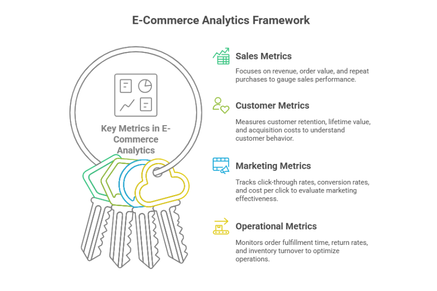

- `Sales Metrics`
  - Revenue
  - Average Order Value (AOV)
  - Repeat Purchase Rate
- `Customer Metrics`
  - Retention Rate
  - Customer Lifetime Value (CLV)
  - Customer Acquisition Cost (CAC)
- `Marketing Metrics`
  - Click-Through Rate (CTR)
  - Conversion Rate
  - Cost Per Click (CPC)
- `Operational Metrics`
  - Order Fulfillment Time
  - Return Rates
  - Inventory Turnover

### Seasonal Sales Impact

#### Historical Trends

- Major events like Flipkart’s Big Billion Days, Amazon Great Indian Festival, and Meesho Mega Blockbuster Sale drive record traffic and sales volumes.
- Flipkart’s Big Billion Days attracts millions of orders, with platforms often seeing 2-3x revenue spikes during these periods.

#### Strategic Adjustments

- `Pricing:` Heavy discounts, flash sales, and exclusive launches to attract buyers.
- `Inventory:` Stockpiling popular items, predictive stocking based on past sales data.
- `Marketing:` Increased ad spend, influencer campaigns, personalized offers, and early access for loyalty members.
- `Logistics:` Temporary expansion of delivery workforce, faster shipping options, and partnerships with third-party logistics providers.

### `Summary Table:` Business Models & Key Strategies

| Platform | Business Model(s) | Data-Driven Practices | Seasonal Sales Tactics |
| --- | --- | --- | --- |
| Flipkart | B2C, Marketplace | AI personalization, dynamic pricing, predictive logistics | Big Billion Days, deep discounts, loyalty perks |
| Amazon India | B2C, Marketplace | Seller analytics, Fulfillment by Amazon (FBA), dynamic pricing | Great Indian Festival, Prime offers |
| Meesho | Social Commerce | Social data analytics, reseller targeting | Mega Blockbuster Sale, reseller incentives |
| Nykaa | Hybrid, D2C | Inventory analytics, private label focus | Beauty/fashion sale events, influencer tie-ups |
| Myntra | Hybrid, D2C | AI/ML personalization, fast delivery | End of Reason Sale, influencer marketing |
| Ajio | Marketplace, D2C | Curated selection, omnichannel analytics | Fashion sales, exclusive launches |

#### Insights for Data Analysis Tasks

- `User segmentation and personalization` are critical for customer retention and conversion, especially during peak sales.
- `Dynamic pricing and inventory analytics` directly impact revenue and operational efficiency.
- `Seasonal sales` require robust forecasting and logistics optimization to handle order surges and minimize returns.
- `Key metrics` (AOV, CLV, CAC, fulfillment time) should be tracked continuously to assess campaign and operational effectiveness.

These insights can guide our data analysis, focusing on how platforms use data to drive growth, optimize operations, and enhance customer experience.